```python
import pandas as pd
import numpy as np
import matplotlib.pyplot as plt
import seaborn as sns
import math
```

# Checking

```python
path = './house_data.csv'
df = pd.read_csv(path)
df.drop(columns=['Unnamed: 0.2',  'Unnamed: 0.1', 'Unnamed: 0', 'id', 'date'], inplace=True, errors='ignore')
df.describe()
```

|  | price | bedrooms | bathrooms | sqft_living | sqft_lot | floors | waterfront | view | condition | grade | sqft_above | sqft_basement | yr_built | yr_renovated | zipcode | lat | long | sqft_living15 | sqft_lot15 | house_age |
| --- | --- | --- | --- | --- | --- | --- | --- | --- | --- | --- | --- | --- | --- | --- | --- | --- | --- | --- | --- | --- |
| count | 2.161300e+04 | 21613.000000 | 21613.000000 | 18528.000000 | 2.161300e+04 | 18530.000000 | 21613.000000 | 21613.000000 | 21613.000000 | 21613.000000 | 21613.000000 | 21184.000000 | 18531.000000 | 21613.000000 | 21613.000000 | 21613.000000 | 21613.000000 | 21613.000000 | 21613.000000 | 21613.000000 |
| mean | 5.401822e+05 | 3.367464 | 2.111900 | 2077.569031 | 1.510697e+04 | 1.492903 | 0.007542 | 0.234303 | 3.409430 | 7.645722 | 1788.390691 | 292.121082 | 1970.896714 | 84.402258 | 98077.939805 | 47.560053 | -122.213896 | 1986.552492 | 12768.455652 | 50.994864 |
| std | 3.673622e+05 | 0.943028 | 0.780697 | 953.971679 | 4.142051e+04 | 0.538562 | 0.086517 | 0.766318 | 0.650743 | 2.020809 | 828.090978 | 442.637777 | 29.406420 | 401.679240 | 53.505026 | 0.138564 | 0.140828 | 685.391304 | 27304.179631 | 29.373411 |
| min | 7.500000e+04 | -5.000000 | -5.000000 | -33323.000000 | 5.200000e+02 | 1.000000 | 0.000000 | 0.000000 | 1.000000 | -234.000000 | 290.000000 | 0.000000 | 1900.000000 | 0.000000 | 98001.000000 | 47.155900 | -122.519000 | 399.000000 | 651.000000 | 7.000000 |
| 25% | 3.219500e+05 | 3.000000 | 1.750000 | 1430.000000 | 5.040000e+03 | 1.000000 | 0.000000 | 0.000000 | 3.000000 | 7.000000 | 1190.000000 | 0.000000 | 1951.000000 | 0.000000 | 98033.000000 | 47.471000 | -122.328000 | 1490.000000 | 5100.000000 | 25.000000 |
| 50% | 4.500000e+05 | 3.000000 | 2.250000 | 1920.000000 | 7.618000e+03 | 1.500000 | 0.000000 | 0.000000 | 3.000000 | 7.000000 | 1560.000000 | 0.000000 | 1975.000000 | 0.000000 | 98065.000000 | 47.571800 | -122.230000 | 1840.000000 | 7620.000000 | 47.000000 |
| 75% | 6.450000e+05 | 4.000000 | 2.500000 | 2550.000000 | 1.068800e+04 | 2.000000 | 0.000000 | 0.000000 | 4.000000 | 8.000000 | 2210.000000 | 560.000000 | 1996.000000 | 0.000000 | 98118.000000 | 47.678000 | -122.125000 | 2360.000000 | 10083.000000 | 71.000000 |
| max | 7.700000e+06 | 33.000000 | 8.000000 | 13540.000000 | 1.651359e+06 | 3.500000 | 1.000000 | 4.000000 | 5.000000 | 13.000000 | 9410.000000 | 4820.000000 | 2015.000000 | 2015.000000 | 98199.000000 | 47.777600 | -121.315000 | 6210.000000 | 871200.000000 | 122.000000 |

```python
df.info()
```

```
<class 'pandas.core.frame.DataFrame'>
RangeIndex: 21613 entries, 0 to 21612
Data columns (total 22 columns):
 #   Column         Non-Null Count  Dtype
---  ------         --------------  -----
 0   price          21613 non-null  float64
 1   bedrooms       21613 non-null  int64
 2   bathrooms      21613 non-null  float64
 3   sqft_living    18528 non-null  float64
 4   sqft_lot       21613 non-null  int64
 5   floors         18530 non-null  float64
 6   waterfront     21613 non-null  int64
 7   view           21613 non-null  int64
 8   condition      21613 non-null  int64
 9   grade          21613 non-null  int64
 10  sqft_above     21613 non-null  int64
 11  sqft_basement  21184 non-null  float64
 12  yr_built       18531 non-null  float64
 13  yr_renovated   21613 non-null  int64
 14  zipcode        21613 non-null  int64
 15  lat            21613 non-null  float64
 16  long           21613 non-null  float64
 17  sqft_living15  21613 non-null  int64
 18  sqft_lot15     21613 non-null  int64
 19  location       21613 non-null  object
 20  style          21613 non-null  object
 21  house_age      21613 non-null  int64
dtypes: float64(8), int64(12), object(2)
memory usage: 3.6+ MB
```

```python
df.head(15)
```

|  | price | bedrooms | bathrooms | sqft_living | sqft_lot | floors | waterfront | view | condition | grade | ... | yr_built | yr_renovated | zipcode | lat | long | sqft_living15 | sqft_lot15 | location | style | house_age |
| --- | --- | --- | --- | --- | --- | --- | --- | --- | --- | --- | --- | --- | --- | --- | --- | --- | --- | --- | --- | --- | --- |
| 0 | 221900.0 | 3 | 1.00 | 1180.0 | 5650 | 1.0 | 0 | 0 | 3 | 7 | ... | 1955.0 | 0 | 98178 | 47.5112 | -122.257 | 1340 | 5650 | Suburban | Contemporary | 67 |
| 1 | 538000.0 | 3 | 2.25 | 2570.0 | 7242 | NaN | 0 | 0 | 3 | 7 | ... | NaN | 1991 | 98125 | 47.7210 | -122.319 | 1690 | 7639 | Suburban | Ranch | 71 |
| 2 | 180000.0 | 2 | 1.00 | 770.0 | 10000 | 1.0 | 0 | 0 | 3 | 6 | ... | 1933.0 | 0 | 98028 | 47.7379 | -122.233 | 2720 | 8062 | Rural | Victorian | 89 |
| 3 | 604000.0 | 4 | 3.00 | 1960.0 | 5000 | 1.0 | 0 | 0 | 5 | 7 | ... | 1965.0 | 0 | 98136 | 47.5208 | -122.393 | 1360 | 5000 | Urban | Colonial | 57 |
| 4 | 510000.0 | 3 | 2.00 | 1680.0 | 8080 | 1.0 | 0 | 0 | 3 | 8 | ... | 1987.0 | 0 | 98074 | 47.6168 | -122.045 | 1800 | 7503 | Suburban | Cape Cod | 35 |
| 5 | 1230000.0 | 4 | 4.50 | 5420.0 | 101930 | 1.0 | 0 | 0 | 3 | 11 | ... | 2001.0 | 0 | 98053 | 47.6561 | -122.005 | 4760 | 101930 | Urban | Colonial | 21 |
| 6 | 257500.0 | 3 | 2.25 | 1715.0 | 6819 | 2.0 | 0 | 0 | 3 | 7 | ... | 1995.0 | 0 | 98003 | 47.3097 | -122.327 | 2238 | 6819 | Urban | Ranch | 27 |
| 7 | 291850.0 | 3 | 1.50 | 1060.0 | 9711 | NaN | 0 | 0 | 3 | 7 | ... | NaN | 0 | 98198 | 47.4095 | -122.315 | 1650 | 9711 | Rural | Ranch | 59 |
| 8 | 229500.0 | 3 | 1.00 | NaN | 7470 | 1.0 | 0 | 0 | 3 | 7 | ... | 1960.0 | 0 | 98146 | 47.5123 | -122.337 | 1780 | 8113 | Rural | Ranch | 62 |
| 9 | 323000.0 | 3 | 2.50 | NaN | 6560 | 2.0 | 0 | 0 | 3 | 7 | ... | 2003.0 | 0 | 98038 | 47.3684 | -122.031 | 2390 | 7570 | Urban | Ranch | 19 |
| 10 | 662500.0 | 3 | 2.50 | 3560.0 | 9796 | 1.0 | 0 | 0 | 3 | 8 | ... | NaN | 0 | 98007 | 47.6007 | -122.145 | 2210 | 8925 | Suburban | Victorian | 57 |
| 11 | 468000.0 | 2 | 1.00 | 1160.0 | 6000 | 1.0 | 0 | 0 | 4 | 7 | ... | 1942.0 | 0 | 98115 | 47.6900 | -122.292 | 1330 | 6000 | Urban | Ranch | 80 |
| 12 | 310000.0 | 3 | 1.00 | 1430.0 | 19901 | 1.5 | 0 | 0 | 4 | 7 | ... | 1927.0 | 0 | 98028 | 47.7558 | -122.229 | 1780 | 12697 | Urban | Cape Cod | 95 |
| 13 | 400000.0 | 3 | 1.75 | NaN | 9680 | 1.0 | 0 | 0 | 4 | 7 | ... | 1977.0 | 0 | 98074 | 47.6127 | -122.045 | 1370 | 10208 | Urban | Ranch | 45 |
| 14 | 530000.0 | 5 | 2.00 | 1810.0 | 4850 | 1.5 | 0 | 0 | 3 | 7 | ... | 1900.0 | 0 | 98107 | 47.6700 | -122.394 | 1360 | 4850 | Urban | Cape Cod | 122 |

15 rows × 22 columns

```python
na_num = df.isna().sum(axis=0)
na_percentage = (df.isna().mean(axis=0)*100).round(2)
pd.DataFrame({
    'na_num': na_num,
    'na_percentage': na_percentage,
})
```

|  | na_num | na_percentage |
| --- | --- | --- |
| price | 0 | 0.00 |
| bedrooms | 0 | 0.00 |
| bathrooms | 0 | 0.00 |
| sqft_living | 3085 | 14.27 |
| sqft_lot | 0 | 0.00 |
| floors | 3083 | 14.26 |
| waterfront | 0 | 0.00 |
| view | 0 | 0.00 |
| condition | 0 | 0.00 |
| grade | 0 | 0.00 |
| sqft_above | 0 | 0.00 |
| sqft_basement | 429 | 1.98 |
| yr_built | 3082 | 14.26 |
| yr_renovated | 0 | 0.00 |
| zipcode | 0 | 0.00 |
| lat | 0 | 0.00 |
| long | 0 | 0.00 |
| sqft_living15 | 0 | 0.00 |
| sqft_lot15 | 0 | 0.00 |
| location | 0 | 0.00 |
| style | 0 | 0.00 |
| house_age | 0 | 0.00 |

```
sqft_living      0.676542
sqft_above       0.605566
sqft_living15    0.585374
Name: price, dtype: float64
```

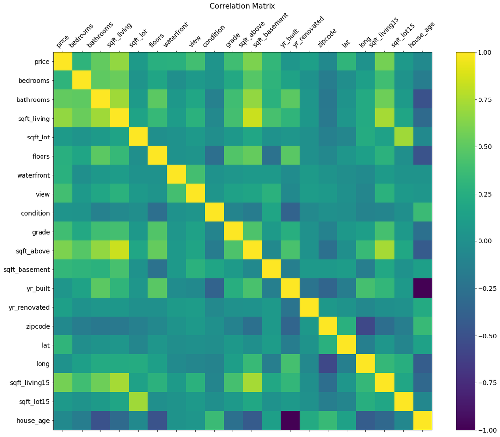

```python
corr_df = df.select_dtypes(['number']).corr()

f = plt.figure(figsize=(19, 15))
plt.matshow(corr_df, fignum=f.number)
plt.xticks(range(df.select_dtypes(['number']).shape[1]), df.select_dtypes(['number']).columns, fontsize=14, rotation=45)
plt.yticks(range(df.select_dtypes(['number']).shape[1]), df.select_dtypes(['number']).columns, fontsize=14)
cb = plt.colorbar()
cb.ax.tick_params(labelsize=14)
plt.title('Correlation Matrix', fontsize=16)
corr_df['price'].sort_values(ascending=False)[1:4]
```

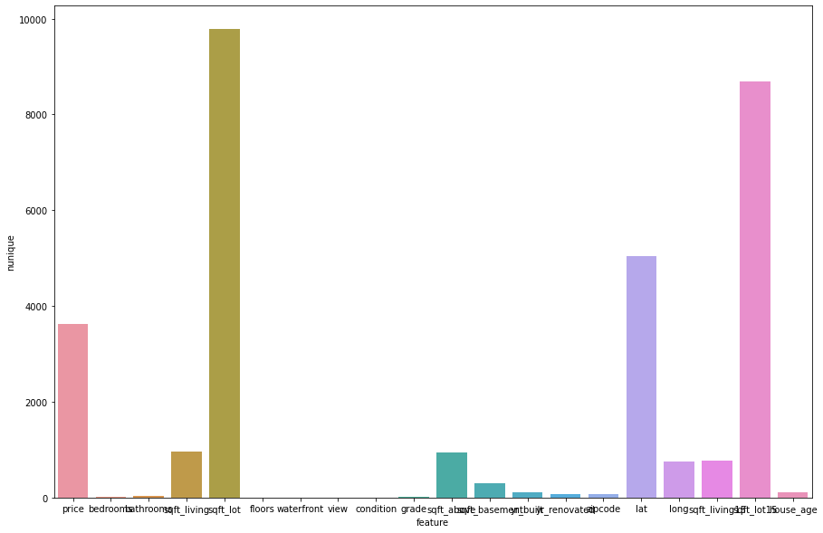

```python
nu = df.select_dtypes(['number']).nunique().reset_index()
nu.columns = ['feature','nunique']
plt.figure(figsize=(15,10))
ax = sns.barplot(x='feature', y='nunique', data=nu)
```

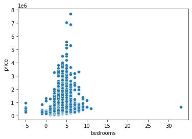

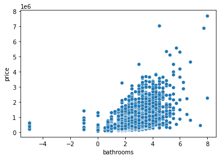

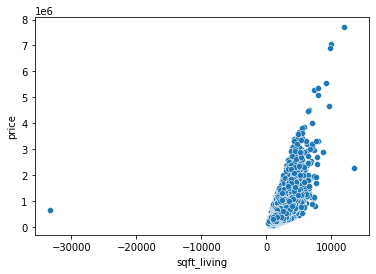

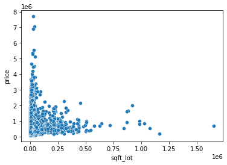

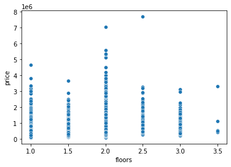

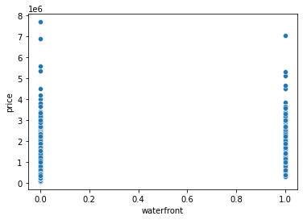

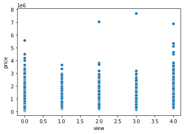

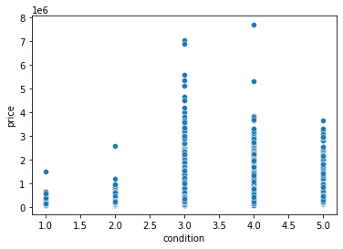

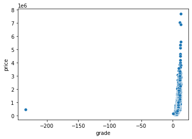

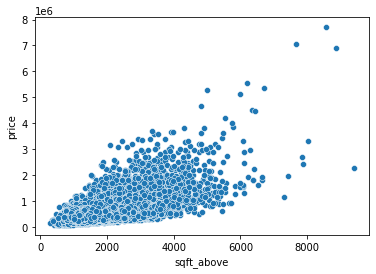

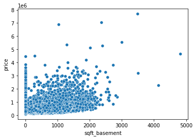

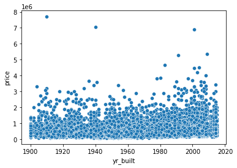

[9 more figures not shown]

```python
column_names = df.columns.tolist()
# Remove the 'price' column from the list of column names
column_names.remove('price')

# Create a plot for each column against the price column
for column in column_names:
    sns.scatterplot(x=column, y='price', data=df)
    plt.show()
```

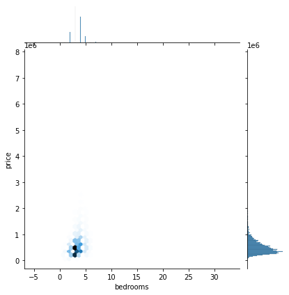

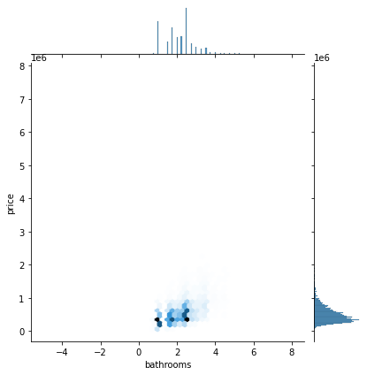

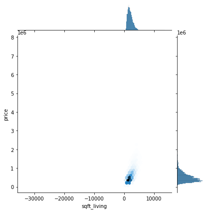

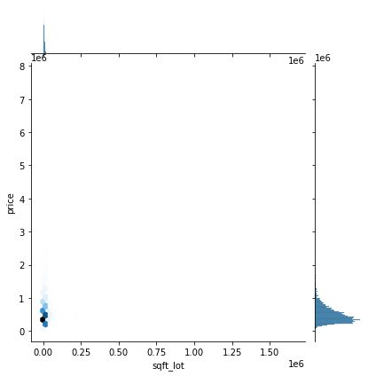

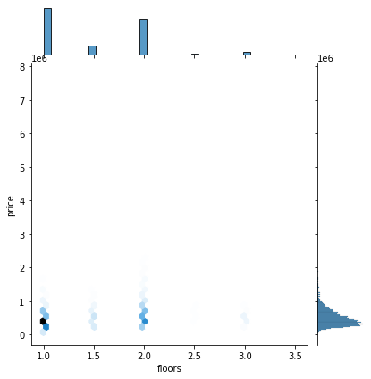

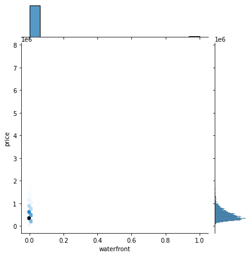

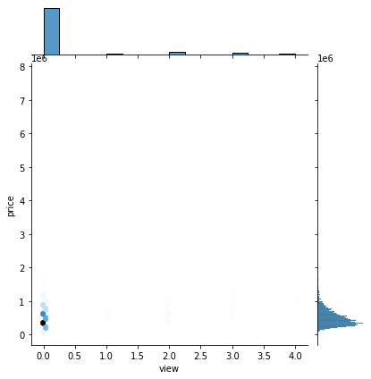

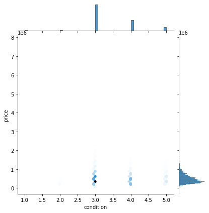

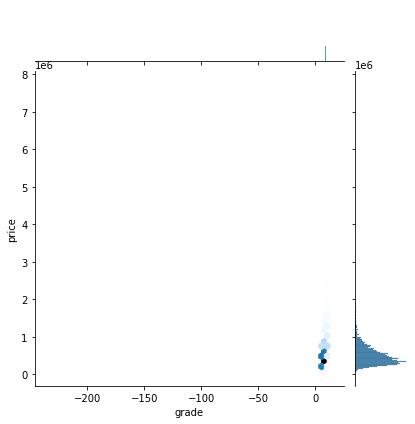

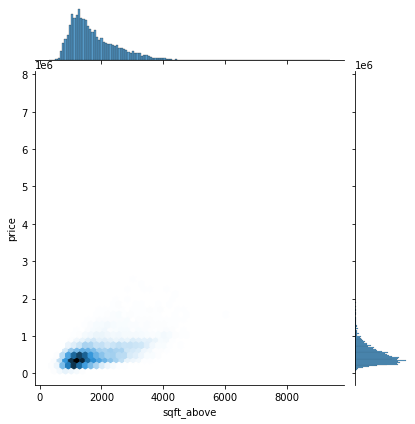

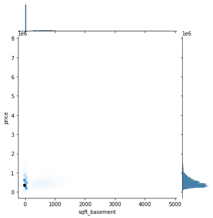

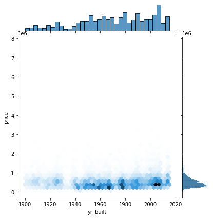

[7 more figures not shown]

```python
column_names = df.select_dtypes('number').columns.tolist()
column_names.remove('price')
for column in column_names:
    sns.jointplot(x=column, y='price', data=df, kind='hex')
    plt.show()
```

# Pre Process

## 1

1. delete rows with missing values instead of columns but in this way we loss some information.
2. Train a model for predicting that value it's good and also hard to do this separately fo every feature.
3. Using Algorithms that support missing values like k-NN

## 2

sqft_living, floors, yr_built and sqft_basement has missingg values and all of them are numerical so i use mean to fill them.

```python
na_cols = ['sqft_living', 'floors', 'yr_built', 'sqft_basement']
means = df[na_cols].mean(axis=0)
df.loc[:,na_cols] = df.loc[:,na_cols].fillna(value=means)
```

```python
grade_mask = df['grade'] > 0
sqft_living_mask = df['sqft_living'] > 0
bedrooms_mask = df['bedrooms'] < 0
bathrooms_mask = df['bathrooms'] < 0
df = df.loc[grade_mask & sqft_living_mask]
# (df.select_dtypes('number') < 0).sum(axis=0)
df.loc[bedrooms_mask, ['bedrooms']] *= -1
df.loc[bathrooms_mask, ['bathrooms']] *= -1
```

## 3

yes at all it's allways good. if we don't do this features with bigger values will have more effect.

```python
numericals_df = df.select_dtypes('number').columns.to_list()

df.loc[:, numericals_df]= (df[numericals_df]- df[numericals_df].mean(axis=0)) / df[numericals_df].std(axis=0)
```

## 4

Two features are strings. first we should encode them and then use the for linear regression.

```python
from sklearn.preprocessing import LabelEncoder
le = LabelEncoder()
# le.fit(df[['location', 'style']])
# le.fit(df[['location', 'style']])
df[['location', 'style']] = df[['location', 'style']].apply(lambda x: le.fit_transform(x))
df.head()
```

|  | price | bedrooms | bathrooms | sqft_living | sqft_lot | floors | waterfront | view | condition | grade | ... | yr_built | yr_renovated | zipcode | lat | long | sqft_living15 | sqft_lot15 | location | style | house_age |
| --- | --- | --- | --- | --- | --- | --- | --- | --- | --- | --- | --- | --- | --- | --- | --- | --- | --- | --- | --- | --- | --- |
| 0 | -0.866354 | -0.398204 | -1.445279 | -1.058070 | -0.228266 | -0.988365 | -0.087175 | -0.305768 | -0.629091 | -0.558814 | ... | -0.583864 | -0.210134 | 1.870053 | -0.352560 | -0.306017 | -0.943309 | -0.260676 | 1 | 2 | 0.544929 |
| 1 | -0.005932 | -0.398204 | 0.174637 | 0.577535 | -0.189831 | 0.000047 | -0.087175 | -0.305768 | -0.629091 | -0.558814 | ... | -0.000063 | 4.746338 | 0.879529 | 1.161477 | -0.746326 | -0.432673 | -0.187832 | 1 | 3 | 0.681103 |
| 2 | -0.980405 | -1.472290 | -1.445279 | -1.540514 | -0.123246 | -0.988365 | -0.087175 | -0.305768 | -0.629091 | -1.409515 | ... | -1.391806 | -0.210134 | -0.933317 | 1.283437 | -0.135574 | 1.070057 | -0.172341 | 0 | 4 | 1.293886 |
| 3 | 0.173720 | 0.675883 | 1.146587 | -0.140248 | -0.243958 | -0.988365 | -0.087175 | -0.305768 | 2.445027 | -0.558814 | ... | -0.216617 | -0.210134 | 1.085109 | -0.283281 | -1.271857 | -0.914130 | -0.284482 | 2 | 1 | 0.204494 |
| 4 | -0.082147 | -0.398204 | -0.149346 | -0.469723 | -0.169600 | -0.988365 | -0.087175 | -0.305768 | -0.629091 | 0.291886 | ... | 0.591325 | -0.210134 | -0.073617 | 0.409510 | 1.199559 | -0.272187 | -0.192813 | 1 | 0 | -0.544463 |

5 rows × 22 columns

## 5

I've dropped some colmuns like id and date because they don't have any information.

## 6

We can use scikit-learn's train_test_split function. or we can use np.choose() function but the typical and food way is train_test_split function.

## 7

In the ML process first, we split the test set and we don't touch them until the end of work. sometimes our model has some hyperparameters that we should fine-tune. so we divide train set to validation and train set to fine-tune these hyperparameters.

# Linear Regression

Main form of simple linear regression function: $$f(x) = \alpha x + \beta$$

- step 1: Compute RSS of the training data

$$ RSS = \Sigma (y_i - (\hat{\beta} + \hat{\alpha} * x_i) )^2 $$

- step 2: Compute the derivatives of the RSS function in term of $\underline{\alpha}$ and $\underline{\beta}$, and set them equal to 0 to find the desired parameters

$$ \frac{\partial RSS}{\partial \beta} = \Sigma (-f(x_i) + \hat{\beta} + \hat{\alpha} * x_i) = 0$$$$ \to \hat{\beta} = \hat{y} - \hat{\alpha} \hat{x} \to (1)$$$$ \frac{\partial RSS}{\partial \alpha} = \Sigma (-2 x_i y_i + 2 \hat{\beta} x_i + 2\hat{\alpha} x_i ^ 2) = 0 \to (2)$$$$ (1) , (2) \to \hat{\alpha} = \frac{\Sigma{(x_i - \hat{x})(y_i - \hat{y})}}{\Sigma{(x_i - \hat{x})^2}} $$

$$ \hat{\beta} = \hat{y} - \hat{\alpha} \hat{x}$$

Based on the formula above, complete this function to compute the parameters of a simple linear regression

```python
def simple_linear_regression(input_feature, output):
    n = len(input_feature)
    sum_y = np.sum(output)
    sum_x = np.sum(input_feature)
    sum_xy = np.dot(input_feature, output)
    sum_x2 = np.dot(input_feature, input_feature)

    intercept = (n * sum_xy - sum_y * sum_x) / (n * sum_x2 - sum_x * sum_x)
    slope = (sum_y - intercept * sum_x) / n

    return (intercept, slope)
```

Now complete this function to predict the value of given data based on the calculated intercept and slope

```python
def get_regression_predictions(input_feature, intercept, slope):
    predicted_values = intercept * input_feature + slope
    return (predicted_values)
```

Now that we have a model and can make predictions let's evaluate our model using Root Mean Square Error (RSME). RMSE is the square root of the mean of the squared differences between the residuals and the residuals is just a fancy word for the difference between the predicted output and the true output.

Complete the following function to compute the RSME of a simple linear regression model given the input_feature, output, intercept and slope:

```python
def get_root_mean_square_error(predicted_values , output):
    # TO DO:

    # Compute the residuals (since we are squaring it doesn't matter which order you subtract)
    res = predicted_values - output
    # square the residuals and add them up
    squared_res = res * res
    # find the mean of the above phrase
    MSE = np.mean(squared_res)
    # calculate the root
    RMSE = np.sqrt(MSE)
    return(RMSE)
```

AS you might guessed, the RMSE has no bound and it is not easy to find out the percentage of fitting the model into data with it. instead, we use R2 score. The R2 score is calculated by comparing the sum of the squared differences between the actual and predicted values of the dependent variable to the total sum of squared differences between the actual and mean values of the dependent variable. Matematically, the R2 score formula is shown as follows:

$$R^2 = 1 - \frac{SSres}{SStot} = 1 - \frac{\sum_{i=1}^{n} (y_{i,true} - y_{i,pred})^2}{\sum_{i=1}^{n} (y_{i,true} - \bar{y}_{true})^2} $$

In this step, complete the following function to calculate the R2 score of a given input_feature, output, intercept, and slope:

```python
def get_r2_score(predicted_values, output):
    res = predicted_values - output
    SSres = np.sum(res * res)
    SStot = np.sum((output - output.mean()) * (output - output.mean()))
    R2_score = 1 - SSres / SStot
    return(R2_score)
```

Now calculate the fitness of the model and explain the outputs

```python
designated_feature_list = ['sqft_living' , 'yr_built' , 'grade' , 'zipcode']
y_true = df['price'].values
for feature in designated_feature_list:
    intercept, slope = simple_linear_regression(df[feature].values, y_true)
    y_pred = get_regression_predictions(df[feature].values, intercept, slope)
    RMSE = get_root_mean_square_error(y_pred, y_true)
    R2 = get_r2_score(y_pred, y_true)
    print(f'feature: {feature}\nRMSE:{RMSE}, R2:{R2}\n')
```

```
feature: sqft_living
RMSE:0.7552895543843123, R2:0.42951129096710194

feature: yr_built
RMSE:0.9987161130661876, R2:0.002519969376353126

feature: grade
RMSE:0.7446266925701004, R2:0.4455054307338029

feature: zipcode
RMSE:0.9985628884642357, R2:0.002826015817954386
```

## 3

1. RSS(Residual Sum of Squares) is a measure of the difference between the predicted and actual values of the dependent variable in a regression model.
2. MSE (Mean Squared Error) is a similar metric to RSS, but it takes the average of the squared differences between the predicted and actual values of the dependent variable. it's more common beacause MSE is robust to number of data.
3. RMSE (Root Mean Squared Error) is the square root of the MSE. It is a measure of the average deviation of the predicted values from the actual values of the dependent variable. RMSE is preferred over MSE because it is in the same units as the dependent variable and is therefore easier to interpret.
4. R2 score (Coefficient of Determination) is a measure of how well the regression model explains the variation in the dependent variable. It is calculated as the proportion of the total variance in the dependent variable that is explained by the regression model. R2 score ranges from 0 to 1, with 1 indicating a perfect fit and 0 indicating that the model provides no improvement over a simple average.

## 4

# Classification

```python
high_mask = df['price'] > df['price'].median()
df['price_level'] = 0
df.loc[high_mask, 'price_level'] = 1
df.drop(columns='price', inplace=True)
```

```python
from sklearn.model_selection import GridSearchCV, train_test_split
from sklearn.metrics import confusion_matrix, ConfusionMatrixDisplay, classification_report
X_train, X_test, y_train, y_test = train_test_split(
                                        df.drop(columns='price_level').values,
                                        df['price_level'].values,
                                        test_size=0.22,
                                        random_state=72
                                        )
```

## Logistic Regression

```python
from sklearn.linear_model import LogisticRegression
log_reg = LogisticRegression()
parameters = {
    'penalty' : ['l2'],
    'C'       : np.logspace(-3,3,7),
    'solver'  : ['newton-cg', 'lbfgs', 'liblinear', 'newton-cholesky'],
}
clf = GridSearchCV(
    estimator=log_reg,
    param_grid=parameters,
    scoring='accuracy',
    cv=10
)
clf.fit(X_train, y_train)
print("Tuned Hyperparameters :", clf.best_params_)
print("Accuracy :",clf.best_score_)
```

```
Tuned Hyperparameters : {'C': 0.1, 'penalty': 'l2', 'solver': 'newton-cg'}
Accuracy : 0.8410069308777823
```

```
train accuracy=0.8420740389178928
              precision    recall  f1-score   support

           0       0.83      0.85      0.84      2365
           1       0.85      0.82      0.84      2390

    accuracy                           0.84      4755
   macro avg       0.84      0.84      0.84      4755
weighted avg       0.84      0.84      0.84      4755
```

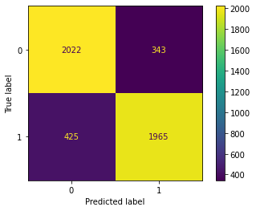

```python
logreg = LogisticRegression(C=0.1, penalty='l2', solver='newton-cg')
logreg.fit(X_train,y_train)

y_pred = logreg.predict(X_test)
cm = confusion_matrix(y_test, y_pred)
disp = ConfusionMatrixDisplay(confusion_matrix=cm, display_labels=clf.classes_)
disp.plot()
print(f'train accuracy={np.mean(y_train == logreg.predict(X_train))}')
print(classification_report(y_test, y_pred))
```

## k-NN

```python
from sklearn.neighbors import KNeighborsClassifier
knn = KNeighborsClassifier()
parameters = {
    'n_neighbors' : np.arange(1, 31),
}
clf = GridSearchCV(
    estimator=knn,
    param_grid=parameters,
    scoring='accuracy',
    cv=10
)
clf.fit(X_train, y_train)
print("Tuned Hyperparameters :", clf.best_params_)
print("Accuracy :",clf.best_score_)
```

```
Tuned Hyperparameters : {'n_neighbors': 13}
Accuracy : 0.8655086222372409
```

```
train accuracy=0.8893569055529188
              precision    recall  f1-score   support

           0       0.86      0.87      0.86      2365
           1       0.87      0.86      0.86      2390

    accuracy                           0.86      4755
   macro avg       0.86      0.86      0.86      4755
weighted avg       0.86      0.86      0.86      4755
```

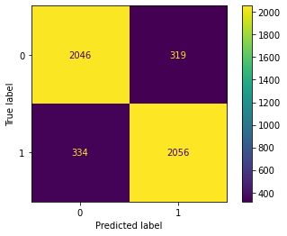

```python
knn = KNeighborsClassifier(n_neighbors=13)
knn.fit(X_train,y_train)
y_pred = knn.predict(X_test)
cm = confusion_matrix(y_test, y_pred)
disp = ConfusionMatrixDisplay(confusion_matrix=cm, display_labels=clf.classes_)
disp.plot()
print(f'train accuracy={np.mean(y_train == knn.predict(X_train))}')
print(classification_report(y_test, y_pred))
```

## Decision Tree

```python
from sklearn.tree import DecisionTreeClassifier
dtc = DecisionTreeClassifier()
parameters = {
    'criterion': ['gini', 'entropy'],
    'max_depth': np.arange(2, 12, 2),
    'min_samples_split': np.arange(2, 10, 2),
    'min_samples_leaf': np.arange(1, 4)
}
clf = GridSearchCV(
    estimator=dtc,
    param_grid=parameters,
    scoring='accuracy',
    cv=10, verbose=True
)
clf.fit(X_train, y_train)
print("Tuned Hyperparameters :", clf.best_params_)
print("Accuracy :",clf.best_score_)
```

```
Fitting 10 folds for each of 120 candidates, totalling 1200 fits
Tuned Hyperparameters : {'criterion': 'gini', 'max_depth': 8, 'min_samples_leaf': 1, 'min_samples_split': 4}
Accuracy : 0.8821194969217612
```

```
train accuracy=0.9082225913621262
              precision    recall  f1-score   support

           0       0.90      0.86      0.88      2365
           1       0.87      0.90      0.89      2390

    accuracy                           0.88      4755
   macro avg       0.88      0.88      0.88      4755
weighted avg       0.88      0.88      0.88      4755
```

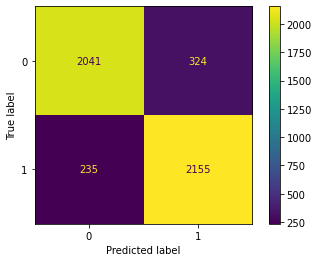

```python
dtc = DecisionTreeClassifier(criterion='entropy', max_depth=8, min_samples_leaf=3, min_samples_split=4)
dtc.fit(X_train,y_train)
y_pred = dtc.predict(X_test)
cm = confusion_matrix(y_test, y_pred)
disp = ConfusionMatrixDisplay(confusion_matrix=cm, display_labels=clf.classes_)
disp.plot()
print(f'train accuracy={np.mean(y_train == dtc.predict(X_train))}')
print(classification_report(y_test, y_pred))
```